# comparison_tGMM_basic_cov_est

Eric Bridgeford

October 19, 2016

## tGMM Approach to Covariance Estimation

#### E Step

Like traditional GMM, our expectation step consists of computing the responsibilities of each potential cluster on our individual data points. \begin{equation} r_{ic} = \frac{\pi_{ic}N(x | \mu_c, \Sigma_c)}{\sum_{c'}\pi_{ic'}N(x | \mu_{c'}, \Sigma_{c'})} \end{equation}

where $r_ic$ represents the given responsibility of a cluster $c$ on time point $i$. This is a relatively intuitive process, as we are essentially considering the probability that a given data point is a member of a cluster and normalizing by the probability that it is in any of the clusters.

#### M Step

Again, much of our process here will look very similar to traditional GMM. As we have information about how the task conditions evolve over time, however, we can skip prediction of the $\pi$ vector entirely. To define some $\rho$ vector, we can convolve a spike train $f$ of condition onsets with a response function that gives the expected proportion of signal at each successive timestep after an impulse, such that:

\begin{equation} \rho_{c} = f_c(i)*h(i) \end{equation}

For each condition $c$, and where $\rho_c$ is defined for each timestep $i$. We normalize our $\rho$ vector to sum to 1 at each time point, calling the normalized vector $\pi$:

\begin{equation} \pi_{ic} = \frac{\rho_{ic}}{\sum_c' \rho_{ic'}} \end{equation}

and now our model is simply a time-variant adaptation of GMM.

The cumulative responsibility of a given cluster $c$

\begin{equation} m_c = \sum_i r_{ic} \end{equation} For updated means. The logic behind the mean maximization is that we consider how much a particular cluster “explains” our $i$th data point, so $\mu$ is more strongly impacted by data points that it explains more effectively. \begin{equation} \hat{\mu_c} = \frac{1}{m_c} \sum_i r_{ic}x_i \end{equation} For updating the covariances. The logi here is again the same; if a point is explained well by a particular distribution, its covariance is more strongly considered than if it isn’t explained by that distribution. \begin{equation} \hat{\Sigma_c} = \frac{1}{m_c} \sum_i r_{ic}(x_i - \hat{\mu_c})^T(x_i - \hat{\mu_c}) \end{equation}

We repeat the expectation and maximization steps until we reach convergence of the likelihood (and consequently the log likelihood) of our predicted clusters matching our data.

\begin{equation} log(p(X)) = \sum_i log[\sum_c \pi_{ic} N(x_i | \mu_c, \Sigma_c)] \end{equation}

## Pseudo Code

[Pseudo](https://github.com/NeuroDataDesign/fngs/blob/gh-pages/reveal/images/week_1019/tGMM_pseudo.pdf)

## Bug Fix

Heavily adjusted the way I wrote the code. Removed all sapply and replaced with traditional for-loops and matrix multiplication, just so that it’s easier to tweak going forward until we finalize the algorithm.

### Super-Simple Example

```r
  require('MASS')
  source('tGMM.R')

  nt <- 100
  ncond <- 2
  nroi <- 1
  mu <- array(0, dim=c(nroi, ncond))
  mu[,1] <- 3
  mu[,2] <- -3
  sigma <- array(1, dim=c(nroi, nroi, ncond))
  pi <- array(0, dim=c(nt, ncond))
  pi[1:50, 1] <- 1
  pi[51:100,2] <- 1

  latent_signal <- array(0, dim=c(ncond, nt, nroi))
  for (i in 1:ncond) {
    library(randomts)
    latent_signal[i,,] <- mvrnorm(n = nt, mu = mu[,i], Sigma <- sigma[,,i])
  }

   observed_signal <- array(sapply(1:dim(latent_signal)[2], function(t) {
    sum(pi[t,]*latent_signal[,t,])
  }), dim=c(nt, nroi))

   test <- tGMM(observed_signal, mu, sigma, pi)
   trusig <- c(var(observed_signal[1:50,1]), var(observed_signal[51:100,1]))
   trumean <- c(mean(observed_signal[1:50,1]), mean(observed_signal[51:100,1]))
   print(paste("True Means>>", max(trumean), min(trumean)))
```

```
## [1] "True Means>> 3.005038629892 -2.85292022219"
```

```r
   print(paste("Predicted Means>>", max(test$means), min(test$means)))
```

```
## [1] "Predicted Means>> 3.005038629892 -2.85292022219"
```

```r
   print(paste("True Cov>>", max(trusig), min(trusig)))
```

```
## [1] "True Cov>> 1.49747209812713 1.20396379356917"
```

```r
   print(paste("Predicted Cov>>", max(test$covs), min(test$covs)))
```

```
## [1] "Predicted Cov>> 1.46752265616459 1.17988451769779"
```

### Notes

Can see from above that we clearly have an unbiased estimator of the mean, and a biased estimator of the covariance (note that the predicted covariance slightly underestimates the true covariance).

## More Complex Example

```r
  nroi <- 2
  ncond <- 3
  nt <- 200
  window <- array(c(0, 1, 1, 1, 1, 0))

  # predict a diagonal matrix for simple case
  predict_mean <- array(0, dim=c(nroi, ncond))
  predict_cov <- array(sapply(1:ncond, function(x) diag(nroi), simplify='array'), dim=c(nroi, nroi, ncond))
  test_dat <- get_sample_data(nt, ncond, nroi, window, offset=4, overlap=4)
```

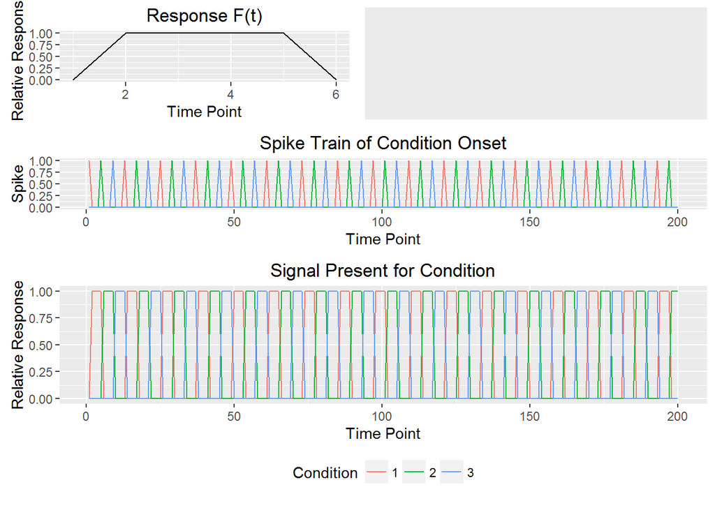

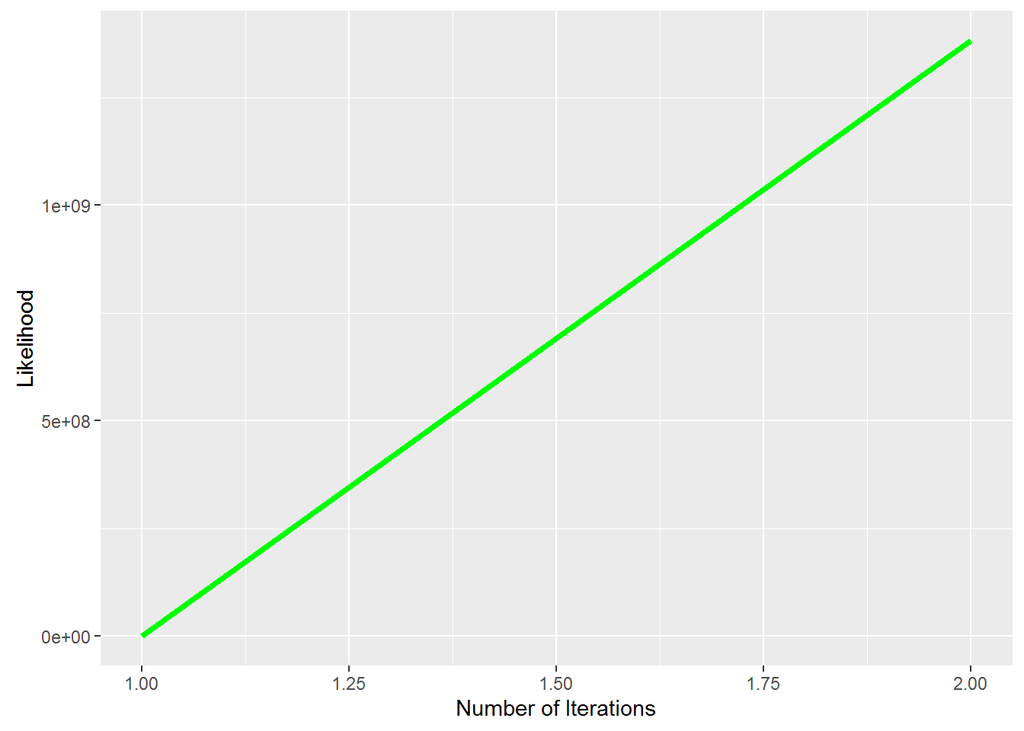

```r
  test <- tGMM(test_dat$x[2:nt,,drop=FALSE], array(0, dim=c(nroi, ncond)), predict_cov,
               test_dat$pi[2:nt,,drop=FALSE])


  llp <- ggplot(data = melt(test$ll), aes(x=1:length(test$ll), y=value)) +
    geom_line(size=1.5, color='green') +
    xlab('Number of Iterations') +
    ylab('Likelihood')
  multiplot(plotlist=list(llp), layout=matrix(c(1), nrow=1, byrow=TRUE))
```

## Notes

Still gives us a bad likelihood sometimes. However, I’ve found the source. The function we are using to compute probabilities leads to a VERY significant, and detrimental, rounding error. Consider the following example:

```r
  prob_gauss <- function(point, mean, cov) {
    require('mvtnorm')
    point <- array(point, dim=c(1, length(point)))
    mean <- array(mean, dim=c(1, length(mean)))
    cov <- array(cov, dim=c(length(mean), length(mean)))
    return(dmvnorm(x=point, mean=mean, sigma=cov))
  }
  # this particular example leads to a NaN responsibility
  pi_vec <- c(0, 0, 1)
  point_test <- readRDS('point_fail.rds')
  cov_test <- readRDS('cov_fail.rds')
  mean_test <- readRDS('mean_fail.rds')
  C <- 3

  s <- sum(sapply(1:C, function(c) pi_vec[c] * prob_gauss(point_test, mean_test[,c], cov_test[,,c])))
  print(s)
```

```
## [1] 0
```

```r
  for (c in 1:C) {
    print(pi_vec[c] * prob_gauss(point_test, mean_test[,c], cov_test[,,c])/s)
  }
```

```
## [1] NaN
## [1] NaN
## [1] NaN
```

### Why this happens

As we can see, dmvnorm reports a value of 0, even when we have a nonzero (but very small) probability of a point being explained by a particular distribution. This leads to a value of NaN for the responsibilities for this point, as we divide by the sum (which here, is zero). A naive solution might be to only divide when it is nonzero, and else just consider the value itself (which would be a value of zero).